# Activity Monitoring Devices Analysis

## Reproducible Research - Data Science Specialization

### Project I

This project makes use of data from a personal activity monitoring device . This device collects data at 5 miute intervals through out the day. The data consists of two months of data from an anonymous individual collected during de months of October and November, 2012 and include the number of steps taken in 5 minute intervals each day.

### Loading and preprocessing data

First we load the data collected from the motion device:

```r
mov <- read.csv("c:/activity.csv", header=TRUE, sep="," , quote = "\"")
mov$date <- as.Date(mov$date, format="%Y/%m%d")
```

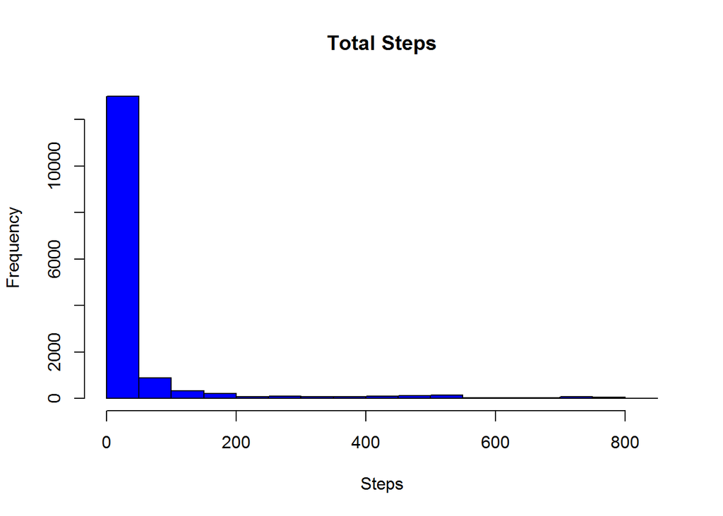

```r
hist(mov$steps, col="blue",main = "Total Steps", xlab="Steps")
```

```r
mean_mov <- mean(mov$steps, na.rm=TRUE)
mean_mov
```

```
## [1] 37.3826
```

```r
median_mov <- median(mov$steps, na.rm=TRUE)
median_mov
```

```
## [1] 0
```

### Daily Activity Pattern

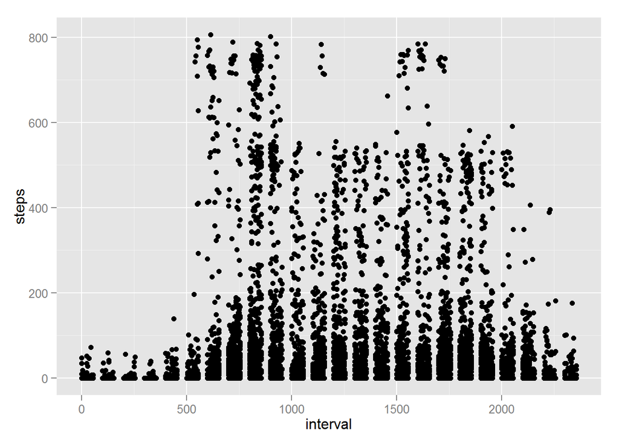

```r
library(ggplot2)
qplot(interval,steps, data=mov )
```

### Missing Values

We calculate the missing values in the data set:

```r
summary(mov)
```

```
##      steps             date          interval
##  Min.   :  0.00   Min.   :NA      Min.   :   0.0
##  1st Qu.:  0.00   1st Qu.:NA      1st Qu.: 588.8
##  Median :  0.00   Median :NA      Median :1177.5
##  Mean   : 37.38   Mean   :NA      Mean   :1177.5
##  3rd Qu.: 12.00   3rd Qu.:NA      3rd Qu.:1766.2
##  Max.   :806.00   Max.   :NA      Max.   :2355.0
##  NA's   :2304     NA's   :17568
```

```r
new_mov <- mov
new_mov$steps[is.na(new_mov$steps)] <- mean_mov
summary(new_mov)
```

```
##      steps             date       interval
##  Min.   :  0.00   Min.   :NA   Min.   :   0.0
##  1st Qu.:  0.00   1st Qu.:NA   1st Qu.: 588.8
##  Median :  0.00   Median :NA   Median :1177.5
##  Mean   : 37.38   Mean   :NA   Mean   :1177.5
##  3rd Qu.: 37.38   3rd Qu.:NA   3rd Qu.:1766.2
##  Max.   :806.00   Max.   :NA   Max.   :2355.0
```

We calculate again the histogram, mean and median with the new data set

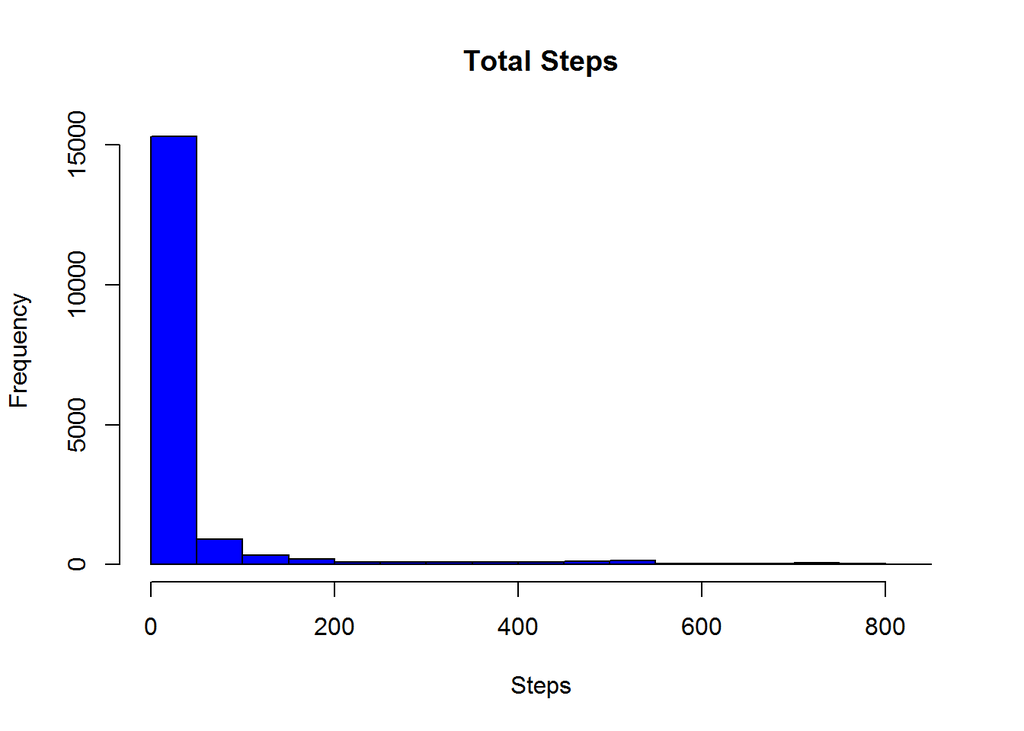

```r
hist(new_mov$steps, col="blue",main = "Total Steps", xlab="Steps")
```

```r
mean_new_mov <- mean(new_mov$steps, na.rm=TRUE)
mean_new_mov
```

```
## [1] 37.3826
```

```r
median_new_mov <- median(new_mov$steps, na.rm=TRUE)
median_new_mov
```

```
## [1] 0
```

As observed, the replace method used has no impact on the mean, but increase the frecuency of the first range of observations

We include a weekday column in the mov data set

```r
mov$weekday <- weekdays(mov$date)
summary(mov)
```

```
##      steps             date          interval        weekday
##  Min.   :  0.00   Min.   :NA      Min.   :   0.0   Length:17568
##  1st Qu.:  0.00   1st Qu.:NA      1st Qu.: 588.8   Class :character
##  Median :  0.00   Median :NA      Median :1177.5   Mode  :character
##  Mean   : 37.38   Mean   :NA      Mean   :1177.5
##  3rd Qu.: 12.00   3rd Qu.:NA      3rd Qu.:1766.2
##  Max.   :806.00   Max.   :NA      Max.   :2355.0
##  NA's   :2304     NA's   :17568
```